#### **Finding 2: Performance of Promotions Lacks**

The graphic below displays the differences between average revenue per sale by company and by the presence of in-store promotions. I have elected to again include the glyphs and numbers above each bar to allow for accurate comparisons from one bar’s results to another. Again, looking at Kellogg’s results yields the insight that, not only are the effects of implementing in-store promotions significant (the bars don’t have overlapping bounds), but that implementing in-store promotions yields higher revenue per sale. Looking towards General Mill’s sections, we again see that the bars overlap. So, while there may appear to be some minuscule benefits to running in-store promotions, the overlapping of the bars indicate that such differences are not very reliable to make such a claim. If the goal of offering in-store promotions is to increase revenue per sale, then I recommend that your firm looks closely at either the level that you discount during in-store promotions (if you reduce the discount and only a small decrease in units sold occurs, there will be net-positive effects on average revenue per sale), or compare your in-store promotions to promotions run by Kelloggs and alter your promotion policies accordingly (as Kellogg’s promotions lead to higher revenue per sale).

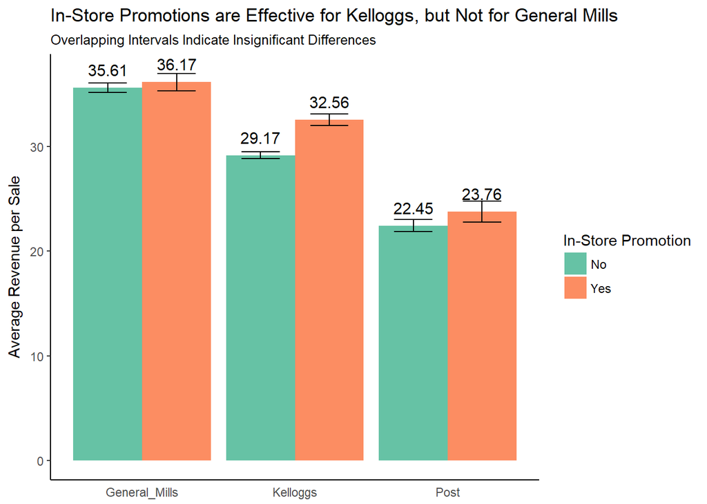

#### **Conclusion:**

In conclusion, while your firm has maintained higher average revenue per sale relative to your competitors there is still room for that margin to grow. More specifically, reflecting upon and improving company policies on in-store promotions and the development and implementation of ad campaigns in ways similar to the current activities of Kelloggs will lead to an increase in average revenue per sale.